# Лабораторная работа №9

Операционные системы

Лебеденко Е.В.

Российский университет дружбы народов, Москва, Россия

11 апреля 2026

# Информация

## Докладчик

- Лебеденко Елена Викторовна
- Студент НКАбд-04-25
- Российский университет дружбы народов
- 1032253535@rudn.ru

# Цель работы

Освоение основных возможностей командной оболочки Midnight Commander. Приобретение навыков практической работы по просмотру каталогов и файлов; манипуляций с ними.

# Задание

## Задание по mc

1. Изучите информацию о mc, вызвав в командной строке man mc.
2. Запустите из командной строки mc, изучите его структуру и меню.
3. Выполните несколько операций в mc, используя управляющие клавиши
4. Выполните основные команды меню левой панели. Оцените степень подробности вывода информации о файлах.
5. Используя возможности подменю Файл, выполните:
- просмотр содержимого текстового файла;
- редактирование содержимого текстового файла (без сохранения результатов редактирования);
- создание каталога;
- копирование в файлов в созданный каталог.

## Задание по mc

6. С помощью соответствующих средств подменю Команда осуществите:
- поиск в файловой системе файла с заданными условиями (например, файла с расширением .c или .cpp, содержащего строку main);
- выбор и повторение одной из предыдущих команд;
- переход в домашний каталог;
- анализ файла меню и файла расширений.
7. Вызовите подменю Настройки . Освойте операции, определяющие структуру экрана mc (Full screen, Double Width, Show Hidden Files и т.д.).

## Задание по встроенному редактору mc

1. Создайте текстовой файл text.txt.
2. Откройте этот файл с помощью встроенного в mc редактора.
3. Вставьте в открытый файл небольшой фрагмент текста, скопированный из любого другого файла или Интернета.
4. Проделайте с текстом следующие манипуляции, используя горячие клавиши:
- 4.1. Удалите строку текста.
- 4.2. Выделите фрагмент текста и скопируйте его на новую строку.
- 4.3. Выделите фрагмент текста и перенесите его на новую строку.

## Задание по встроенному редактору mc

- 4.4. Сохраните файл.
- 4.5. Отмените последнее действие.
- 4.6. Перейдите в конец файла (нажав комбинацию клавиш) и напишите некоторый текст.
- 4.7. Перейдите в начало файла (нажав комбинацию клавиш) и напишите некоторый текст.
- 4.8. Сохраните и закройте файл.
5. Откройте файл с исходным текстом на некотором языке программирования (например C или Java)
6. Используя меню редактора, включите подсветку синтаксиса, если она не включена, или выключите, если она включена.

# Теоретическое введение

Midnight Commander (mc) — это псевдографическая командная оболочка для UNIX/Linux систем, предоставляющая удобный интерфейс для работы с файловой системой. Рабочее пространство mc организовано в виде двух панелей, на которых отображаются списки файлов текущих каталогов, что упрощает навигацию и выполнение файловых операций. Управление mc осуществляется как с помощью функциональных клавиш F1–F10, так и через систему меню (Левая панель, Файл, Команда, Настройки, Правая панель). В состав mc входит встроенный редактор, вызываемый по клавише F4, который поддерживает основные операции редактирования текста, а также подсветку синтаксиса для различных языков программирования. Освоение возможностей Midnight Commander позволяет повысить эффективность работы с файлами и каталогами в командной среде операционной системы.

# Выполнение лабораторной работы

## Задание по mc

Изучаю информацию о mc, вызвав в командной строке man mc.

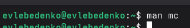

man mc

## Задание по mc

Запускаю из командной строки mc, изучаю его структуру и меню.

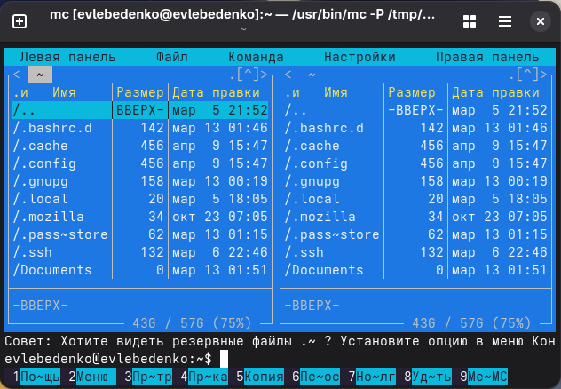

Запуск mc

## Задание по mc

3. Выполните несколько операций в mc, используя управляющие клавиши:
- операции с панелями
- выделение/отмена выделения файлов
- копирование/перемещение файлов
- получение информации о размере и правах доступа на файлы и/или каталоги

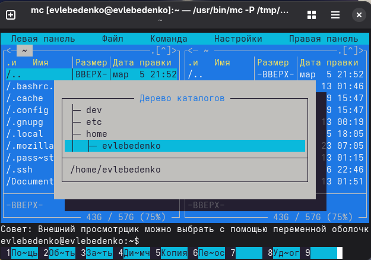

Работа с панелями

## Задание по mc

Выполняю основные команды меню левой панели (Информация, Дерево). По моему не скромному мнению степень подробности вывода информации о файлах вполне высокая (права, владелец, размер и тд)

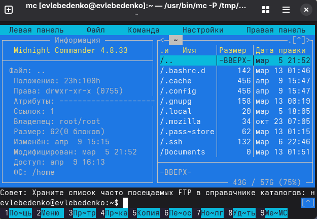

Меню левой панели

## Задание по mc

5. Используя возможности подменю Файл , выполняю:
- просмотр содержимого текстового файла
- редактирование содержимого текстового файла (без сохранения результатов редактирования)
- создание каталога
- копирование в файлов в созданный каталог

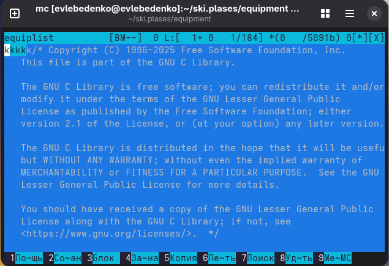

Возможности подменю Файл

## Задание по mc

6. С помощью соответствующих средств подменю Команда осуществляю:
- поиск в файловой системе файла с заданными условиями (например, файла с расширением .c или .cpp, содержащего строку main)
- выбор и повторение одной из предыдущих команд
- переход в домашний каталог
- анализ файла меню и файла расширений

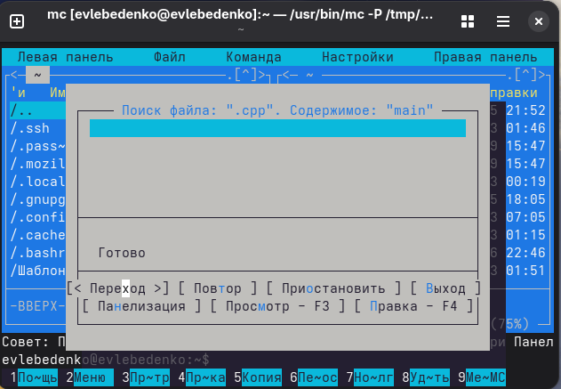

Команда

## Задание по mc

Вызываю подменю Настройки . Осваиваю операции, определяющие структуру экрана mc (Full screen, Double Width, Show Hidden Files и т.д.).

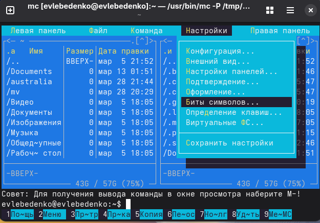

Настройки

## Задание по встроенному редактору mc

Создаю текстовой файл text.txt (touch). Открываю этот файл с помощью встроенного в mc редактора.

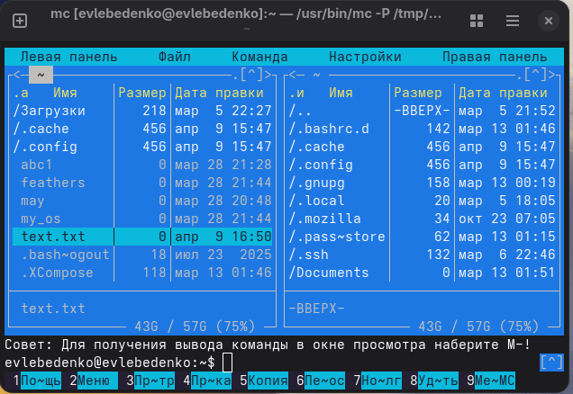

Файл text.txt

## Задание по встроенному редактору mc

9. Вставляю в открытый файл небольшой фрагмент текста, скопированный из любого другого файла или Интернета. Проделываю с текстом следующие манипуляции, используя горячие клавиши:
- Удаляю строку текста
- Выделяю фрагмент текста и копирую его на новую строку
- Выделяю фрагмент текста и переношу его на новую строку
- Сохраняю файл
- Отменяю последнее действие
- Перехожу в конец файла (нажав комбинацию клавиш)
- Перехожу в начало файла (нажав комбинацию клавиш)
- Сохраняю и закрываю файл

## Задание по встроенному редактору mc

Открываю файл с исходным текстом на C++. Используя меню редактора, выключаю подсветку синтаксиса

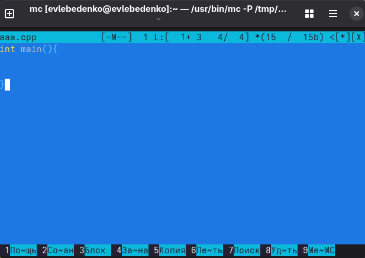

Файл на C++

# Выводы

Во время выполнения лабораторной работы я освоила основные возможности командной оболочки Midnight Commander, приобрела навыки практической работы по просмотру каталогов и файлов; манипуляций с ними